# Models

```r
library(tidyverse)
library(modelr)
library(broom)
# Import wages here

# Fall back in case you cannot load wages
 wages <- heights %>%
    filter(income > 0) %>%
    mutate(marital = as.character(marital),
           sex = as.character(sex))
```

## Your Turn 1

- Change the working directory to `04-Models`.
- Then import `wages.xlsx` as wages and *copy the code to your setup chunk*.
- Be sure to set NA: to NA.

```r
wages
```

```
## # A tibble: 5,266 x 8
##    income height weight   age marital  sex    education  afqt
##     <int>  <dbl>  <int> <int> <chr>    <chr>      <int> <dbl>
##  1  19000     60    155    53 married  female        13  6.84
##  2  35000     70    156    51 married  female        10 49.4
##  3 105000     65    195    52 married  male          16 99.4
##  4  40000     63    197    54 married  female        14 44.0
##  5  75000     66    190    49 married  male          14 59.7
##  6 102000     68    200    49 divorced female        18 98.8
##  7  70000     64    160    54 divorced female        12 50.3
##  8  60000     69    162    55 divorced male          12 89.7
##  9 150000     69    194    54 divorced male          13 96.0
## 10 115000     64    145    53 married  female        16 67.0
## # … with 5,256 more rows
```

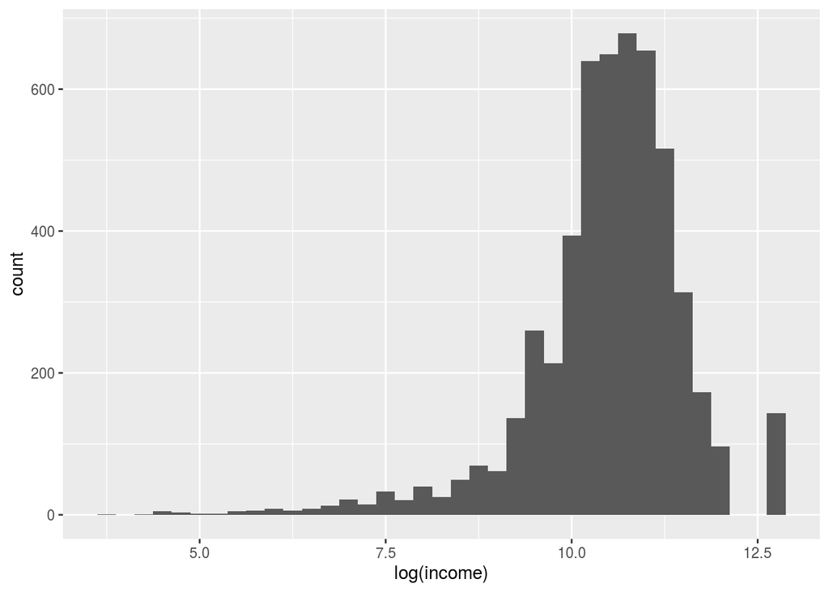

```r
wages %>%
 ggplot(aes(log(income))) + geom_histogram(binwidth = 0.25)
```

## Your Turn 2

Fit the model on the slide and then examine the output. What does it look like?

```r
mod_e <- lm(log(income) ~ education, data = wages)
mod_e
```

```
##
## Call:
## lm(formula = log(income) ~ education, data = wages)
##
## Coefficients:
## (Intercept)    education
##      8.5577       0.1418
```

```r
class(mod_e)
```

```
## [1] "lm"
```

## Your Turn 3

Use a pipe to model `log(income)` against `height`. Then use broom and dplyr functions to extract:

1. The **coefficient estimates** and their related statistics
2. The **adj.r.squared** and **p.value** for the overall model

```r
mod_h <- wages %>%
  lm(log(income) ~ height, data = .)
mod_h %>%
  tidy()
```

```
## # A tibble: 2 x 5
##   term        estimate std.error statistic   p.value
##   <chr>          <dbl>     <dbl>     <dbl>     <dbl>
## 1 (Intercept)   6.98     0.237        29.4 4.13e-176
## 2 height        0.0520   0.00352      14.8 2.44e- 48
```

```r
mod_h %>%
 glance() %>%
 select(adj.r.squared, p.value)
```

```
## # A tibble: 1 x 2
##   adj.r.squared  p.value
##           <dbl>    <dbl>
## 1        0.0396 2.44e-48
```

```r
mod_h %>%
 tidy() %>% filter(p.value < 0.05)
```

```
## # A tibble: 2 x 5
##   term        estimate std.error statistic   p.value
##   <chr>          <dbl>     <dbl>     <dbl>     <dbl>
## 1 (Intercept)   6.98     0.237        29.4 4.13e-176
## 2 height        0.0520   0.00352      14.8 2.44e- 48
```

```r
mod_e %>%
 tidy() %>% filter(p.value < 0.05)
```

```
## # A tibble: 2 x 5
##   term        estimate std.error statistic   p.value
##   <chr>          <dbl>     <dbl>     <dbl>     <dbl>
## 1 (Intercept)    8.56    0.0733      117.  0.
## 2 education      0.142   0.00530      26.7 8.41e-148
```

```r
mod_eh <- wages %>%
 lm(log(income) ~ education + height, data = .)
mod_eh %>%
 tidy()
```

```
## # A tibble: 3 x 5
##   term        estimate std.error statistic   p.value
##   <chr>          <dbl>     <dbl>     <dbl>     <dbl>
## 1 (Intercept)   5.35     0.231        23.1 1.00e-112
## 2 education     0.139    0.00521      26.6 7.12e-147
## 3 height        0.0483   0.00331      14.6 2.50e- 47
```

## Your Turn 4

Model `log(income)` against `education` and `height` and `sex`. Can you interpret the coefficients?

```r
mod_ehs <- wages %>%
  lm(log(income) ~ education + height + sex, data = .)

mod_ehs %>%
  tidy()
```

```
## # A tibble: 4 x 5
##   term        estimate std.error statistic   p.value
##   <chr>          <dbl>     <dbl>     <dbl>     <dbl>
## 1 (Intercept)  7.79      0.307       25.3  9.41e-134
## 2 education    0.148     0.00520     28.5  5.16e-166
## 3 height       0.00673   0.00479      1.40 1.61e-  1
## 4 sexmale      0.462     0.0389      11.9  5.02e- 32
```

```r
wages <-
  wages %>%
  mutate(sex = factor(sex, levels = c('male', 'female')))
```

```r
wages %>%
  lm(log(income) ~ education + height + sex, data = .) %>%
  tidy()
```

```
## # A tibble: 4 x 5
##   term        estimate std.error statistic   p.value
##   <chr>          <dbl>     <dbl>     <dbl>     <dbl>
## 1 (Intercept)  8.25      0.335       24.6  4.68e-127
## 2 education    0.148     0.00520     28.5  5.16e-166
## 3 height       0.00673   0.00479      1.40 1.61e-  1
## 4 sexfemale   -0.462     0.0389     -11.9  5.02e- 32
```

## Your Turn 5

Add `+ geom_smooth(method = lm)` to the code below. What happens?

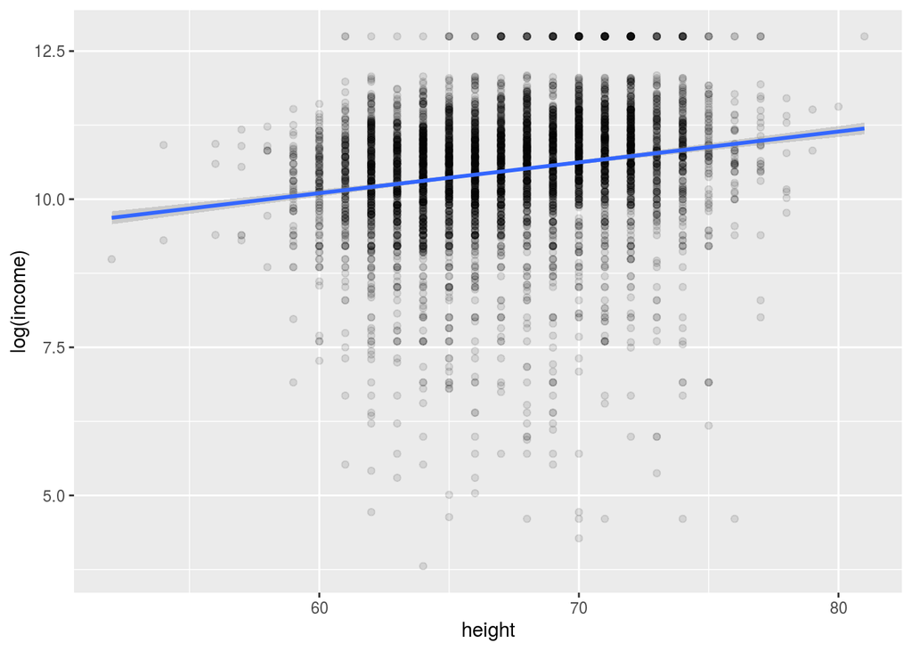

```r
wages %>%
     ggplot(aes(x = height, y = log(income))) +
     geom_point(alpha = 0.1) +
  geom_smooth(method = lm)
```

## Help Me

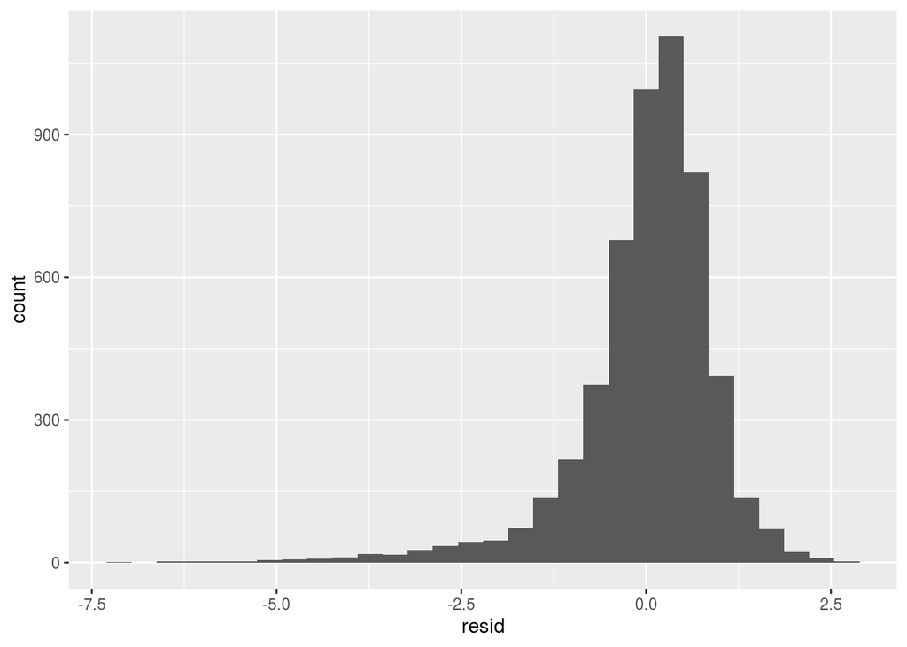

```r
wages %>%
 add_residuals(mod_ehs) %>%
 ggplot() +
 geom_histogram(aes(resid))
```

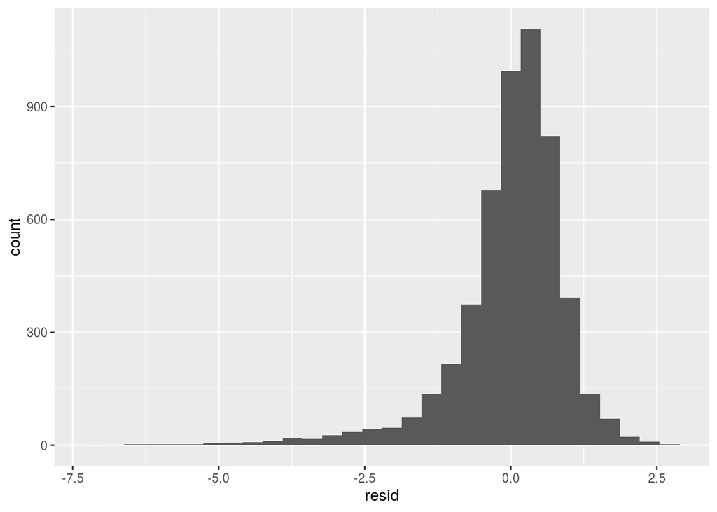

```r
wages %>%
 add_residuals(mod_ehs) %>%
 ggplot() +
 geom_histogram(aes(resid))
```

```r
wages %>%
  spread_residuals(mod_h, mod_eh, mod_ehs)
```

```
## # A tibble: 5,266 x 11
##    income height weight   age marital sex   education  afqt  mod_h mod_eh
##     <int>  <dbl>  <int> <int> <chr>   <fct>     <int> <dbl>  <dbl>  <dbl>
##  1  19000     60    155    53 married fema…        13  6.84 -0.250 -0.198
##  2  35000     70    156    51 married fema…        10 49.4  -0.159  0.346
##  3 105000     65    195    52 married male         16 99.4   1.20   0.854
##  4  40000     63    197    54 married fema…        14 44.0   0.339  0.263
##  5  75000     66    190    49 married male         14 59.7   0.811  0.747
##  6 102000     68    200    49 divorc… fema…        18 98.8   1.01   0.403
##  7  70000     64    160    54 divorc… fema…        12 50.3   0.846  1.05
##  8  60000     69    162    55 divorc… male         12 89.7   0.432  0.656
##  9 150000     69    194    54 divorc… male         13 96.0   1.35   1.43
## 10 115000     64    145    53 married fema…        16 67.0   1.34   0.993
## # … with 5,256 more rows, and 1 more variable: mod_ehs <dbl>
```

```r
wages %>%
  gather_residuals(mod_h, mod_eh, mod_ehs)
```

```
## # A tibble: 15,798 x 10
##    model income height weight   age marital  sex    education  afqt  resid
##    <chr>  <int>  <dbl>  <int> <int> <chr>    <fct>      <int> <dbl>  <dbl>
##  1 mod_h  19000     60    155    53 married  female        13  6.84 -0.250
##  2 mod_h  35000     70    156    51 married  female        10 49.4  -0.159
##  3 mod_h 105000     65    195    52 married  male          16 99.4   1.20
##  4 mod_h  40000     63    197    54 married  female        14 44.0   0.339
##  5 mod_h  75000     66    190    49 married  male          14 59.7   0.811
##  6 mod_h 102000     68    200    49 divorced female        18 98.8   1.01
##  7 mod_h  70000     64    160    54 divorced female        12 50.3   0.846
##  8 mod_h  60000     69    162    55 divorced male          12 89.7   0.432
##  9 mod_h 150000     69    194    54 divorced male          13 96.0   1.35
## 10 mod_h 115000     64    145    53 married  female        16 67.0   1.34
## # … with 15,788 more rows
```

## Your Turn 6

Use `gather_residuals` to complete the code below, which compares the residuals of all three models, `mod_h`, `mod_eh`, and `mod_ehs`.

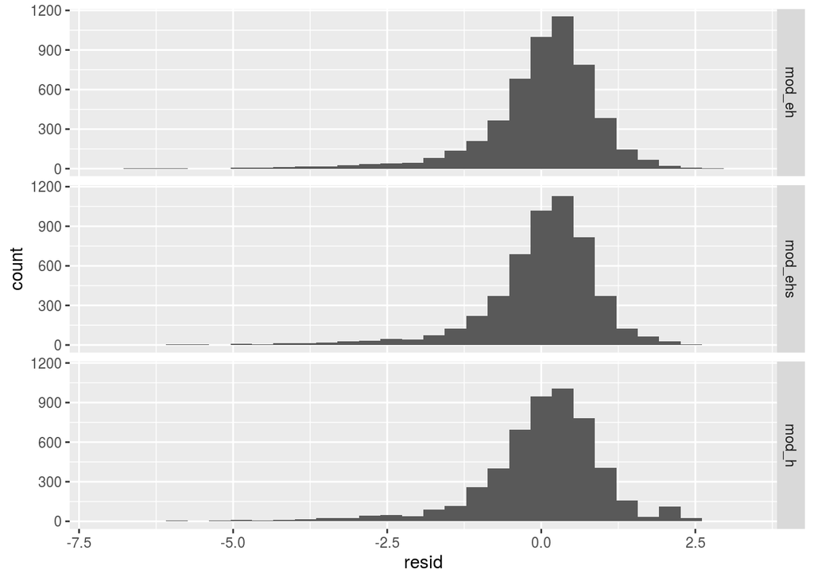

```r
# In case you haven't made the three models
mod_h <- wages %>% lm(log(income) ~ height, data = .)
mod_eh <- wages %>% lm(log(income) ~ education + height, data = .)
mod_ehs <- wages %>% lm(log(income) ~ education + height + sex, data = .)

# Be sure to remove or comment out each _ before running the code
wages %>%
  gather_residuals(mod_h, mod_eh, mod_ehs) %>%
  ggplot() +
    geom_histogram(aes(x = resid)) +
    facet_grid(model ~ .)
```

# Take Aways

- Use `glance()`, `tidy()`, and `augment()` from the **broom** package to return model values in a data frame.
- Use `add_predictions()` or `gather_predictions()` or `spread_predictions()` from the **modelr** package to visualize predictions.
- Use `add_residuals()` or `gather_residuals()` or `spread_residuals()` from the **modelr** package to visualize residuals.